# Introduction

## Compte Rendu d'Évaluation des Performances : Filtres de Bloom vs. Ensembles SET avec Redis

L'objectif de cette évaluation était de comparer les performances des filtres de Bloom avec RedisBloom par rapport aux ensembles SET de Redis dans la détection de doublons au sein d'un ensemble de données CSV. Les tests ont été réalisés avec des conditions expérimentales identiques pour assurer des résultats cohérents.

### Conditions Expérimentales

- **Version Python :** Python 3.11.3
- **Machine Utilisée :** Ordinateur portable équipé d'un processeur Intel Core i3-1215U et de 8 Go de RAM.
- **Environnement Redis :** Même version de Redis utilisée pour les deux tests ( REDIS UTILISEE DEPUIS UN CONTENEUR DOCKER SUR LE PORT 6379).
- **Bibliothèque Redis Python :** Même bibliothèque Redis Python utilisée pour les deux tests.
- **Date des Expériences :** Les tests ont été effectués le même jour.
- **Charge de la Machine :** La machine était dans des conditions de charge similaires pour les deux expériences.

### Interprétation des Résultats

Cependant il peut être intéressant de faire les tests a plus grande échelles sur des machines différentes car le test sur ma machine uniquement ne peut pas être pris comme une valeur absolue

## Publication et Abonnement avec Redis

### Fonctionnement de Base

- **Publication (Publish)** : Envoyer un message à un canal spécifique.
- **Abonnement (Subscribe)** : Écouter et recevoir des messages envoyés à un canal.

### Exemple d'Utilisation : Envoi de Messages Périodiques

#### Script de l'Éditeur (Publisher)

Cet exemple montre comment un éditeur peut envoyer des messages périodiquement sur un canal Redis.

```python
import redis
import time

def publish_messages(channel):
    r = redis.Redis()
    message = "SALUT"

    while True:
        r.publish(channel, message)
        print(f"Message publié : {message}")
        time.sleep(3)  # Attendre 3 secondes

channel_name = "mon_canal"
publish_messages(channel_name)
```

#### Script de l'Abonné (Subscriber)

L'abonné écoute les messages publiés sur un canal spécifique.

**Explication** :

- Le script se connecte à Redis et s'abonne au canal spécifié.
- Il écoute indéfiniment les messages sur ce canal et les affiche lorsqu'ils sont reçus.

```python
import redis

def subscribe_to_channel(channel):
    r = redis.Redis()
    pubsub = r.pubsub()
    pubsub.subscribe(channel)

    print(f"Abonné au canal : {channel}")
    for message in pubsub.listen():
        if message['type'] == 'message':
            print(f"Message reçu : {message['data'].decode()}")

# Exemple d'utilisation
channel_name = "mon_canal"
subscribe_to_channel(channel_name)
```

```
Abonné au canal : mon_canal
```

# PARTIE 3 :MongoDB

MongoDB est un système de gestion de base de données NoSQL orienté document qui offre une grande flexibilité pour le stockage et la manipulation de données. Il est particulièrement adapté pour gérer des données semi-structurées ou non structurées, et il permet de stocker des documents au format JSON .

## Installation de MongoDB et du Pilote Python

Pour ce projet, MongoDB a été installé dans un conteneur Docker, avec le serveur MongoDB écoutant sur le port 27017:27017. De plus, le pilote Python "pymongo" a été installé pour permettre l'interaction entre le script Python et la base de données MongoDB. L'installation du pilote peut être réalisée en utilisant la commande `!pip install pymongo`.

Cette configuration nous permet d'utiliser MongoDB comme système de gestion de base de données pour notre projet, en tirant parti de sa flexibilité et de ses performances pour stocker et gérer des données.

```python
!pip install pymongo
```

### Decouverte mongodb

Dans cette premiere partie je me suis un peu découvert a mongodb en faisant des requêtes simples pour m'initier un peu a la syntaxe

```python
from pymongo import MongoClient

# Connexion à la base de données MongoDB locale
client = MongoClient('localhost', 27017)

# Accès à une base de données spécifique
db = client['ma_base_de_donnees']

# Accès à une collection spécifique
collection = db['ma_collection']
```

```python
# Création d'un nouveau document
document = {'nom': 'Alice', 'age': 25, 'email': 'alice@example.com'}

# Insertion du document dans la collection
resultat_insertion = collection.insert_one(document)
print(f"Document inséré avec l'ID: {resultat_insertion.inserted_id}")


# Vérification de l'insertion en récupérant le document par son ID
document_insere = collection.find_one({'_id': resultat_insertion.inserted_id})
print(f"Document récupéré : {document_insere}")
```

```
Document inséré avec l'ID: 6572cec9cc9366e4e8907953
Document récupéré : {'_id': ObjectId('6572cec9cc9366e4e8907953'), 'nom': 'Alice', 'age': 25, 'email': 'alice@example.com'}
```

```python
# On change l'age par 26
collection.update_one({'nom': 'Alice'}, {'$set': {'age': 26}})


document_mis_a_jour = collection.find_one({'nom': 'Alice'})
print(f"Document après mise à jour : {document_mis_a_jour}")
```

```
Document après mise à jour : {'_id': ObjectId('6572cd73cc9366e4e890794b'), 'nom': 'Alice', 'age': 26, 'email': 'alice@example.com'}
```

```python
documents_25_ans = collection.find({'age': 25})
print("Documents avec un âge de 25 ans :")
for doc in documents_25_ans:
    print(doc)
```

```
Documents avec un âge de 25 ans :
{'_id': ObjectId('6572cd98cc9366e4e890794c'), 'nom': 'Alice', 'age': 25, 'email': 'alice@example.com'}
{'_id': ObjectId('6572cdbbcc9366e4e890794d'), 'nom': 'Alice', 'age': 25, 'email': 'alice@example.com'}
{'_id': ObjectId('6572cdc2cc9366e4e890794e'), 'nom': 'Alice', 'age': 25, 'email': 'alice@example.com'}
{'_id': ObjectId('6572ce2acc9366e4e890794f'), 'nom': 'Alice', 'age': 25, 'email': 'alice@example.com'}
{'_id': ObjectId('6572ce60cc9366e4e8907950'), 'nom': 'Alice', 'age': 25, 'email': 'alice@example.com'}
{'_id': ObjectId('6572ceabcc9366e4e8907951'), 'nom': 'Alice', 'age': 25, 'email': 'alice@example.com'}
{'_id': ObjectId('6572ceb8cc9366e4e8907952'), 'nom': 'Alice', 'age': 25, 'email': 'alice@example.com'}
{'_id': ObjectId('6572cec9cc9366e4e8907953'), 'nom': 'Alice', 'age': 25, 'email': 'alice@example.com'}
```

```python
# Mise à jour de documents
resultat_mise_a_jour = collection.update_one({'nom': 'Alice'}, {'$set': {'age': 26}})
print(f"Nombre de documents mis à jour : {resultat_mise_a_jour.modified_count}")
```

```
Nombre de documents mis à jour : 1
```

```python
# Suppression de documents
resultat_suppression = collection.delete_one({'nom': 'Alice'})
print(f"Nombre de documents supprimés : {resultat_suppression.deleted_count}")
```

```
Nombre de documents supprimés : 1
```

```python
client.close()
```

## Utilisation de la jointure dans le cadre de mongodb

Au tout début du projet nous avions créer un script pour faire une jointure maintenant ce que nous voudrions faire dans mongodb c'est d'alimenter deux collections ici `chemin_avions` et `chemin_vols` avec les fichiers `avions.json` et `vols.json` pour ma part et ensuite de faire une jointure mais en utilisant cette fois ci les deux collections et non les fichiers json directement pour pouvoir créer une troisieme collection `jointure_avions_vols`qui elle contiendra la jointure .

## Introduction aux Index dans MongoDB

Dans MongoDB, les index jouent un rôle crucial dans l'optimisation des performances des requêtes. Un index dans MongoDB est une structure de données spéciale qui améliore la vitesse des opérations de recherche au sein des collections. Lorsqu'un index est créé sur un champ, MongoDB utilise cet index pour accéder rapidement aux données sans avoir à parcourir l'ensemble de la collection. Cela est particulièrement utile pour les grandes bases de données, où les recherches sans index peuvent devenir lentes et coûteuses en ressources.

## Comparaison des Performances : MongoDB Avec Index vs Sans Index

Maintenant, nous allons effectuer des tests pour illustrer l'impact des index sur les performances des requêtes dans MongoDB. Nous allons donc commencer par un script qui mesure les performance de MongoDB en utilisant les indexes et ensuite nous ferons un test sans les index

```python
#
# Performance of MongoDB with indexes
#
import csv
from json import dumps
import time

def perf_mongo(csv_file, n):

    from pymongo import MongoClient

    myclient = MongoClient()
    mydb = myclient["mydatabase"]
    mycol = mydb["mycollection"]
    # Empty the collection
    mycol.drop()
    # Create an index for the collection
    mycol.create_index([ ('M', 1) ])

    with open(csv_file, encoding = 'utf-8') as csvfile:
        my_reader = csv.DictReader(csvfile,delimiter='\t')
        my_data = [my_row for my_row in my_reader]
        #print(my_data)
        pres = dup = 0
        print('Start performance eval over',n,'inputs')
        # get the start time
        st = time.process_time()
        for my_row in my_data[0:n]:
            # print(my_row['M'],type(my_row['M']))
            #
            # find and replace <=> test if key exists
            #
            mycol.replace_one({my_row['M']: 1},{my_row['M']:1},upsert=True,hint=[ ('M', 1) ])
        # get the end time
        et = time.process_time()
        # get execution time
        res = et - st
        print('CPU Execution time:', res, 'seconds')
        print('We found',n - mycol.count_documents({}),'duplicates in the input')
        print()
        print('Wall time (also known as clock time or wall-clock time) is simply the total time')
        print('elapsed during the measurement. Itâ€™s the time you can measure with a stopwatch.')
        print('It is the difference between the time at which a program finished its execution and')
        print('the time at which the program started. It also includes waiting time for resources.')
        print()
        print('CPU Time, on the other hand, refers to the time the CPU was busy processing')
        print('the programâ€™s instructions. The time spent waiting for other task to complete')
        print('(like I/O operations) is not included in the CPU time. It does not include')
        print('the waiting time for resources.')
#Step 1

perf_mongo("C:\\Users\\ilyes\\Desktop\\Bddcsv\\DEMO.csv", 10000)
```

```
Start performance eval over 10000 inputs
CPU Execution time: 0.34375 seconds
We found 1062 duplicates in the input

Wall time (also known as clock time or wall-clock time) is simply the total time
elapsed during the measurement. Itâ€™s the time you can measure with a stopwatch.
It is the difference between the time at which a program finished its execution and
the time at which the program started. It also includes waiting time for resources.

CPU Time, on the other hand, refers to the time the CPU was busy processing
the programâ€™s instructions. The time spent waiting for other task to complete
(like I/O operations) is not included in the CPU time. It does not include
the waiting time for resources.
```

```python
import csv
import time
from pymongo import MongoClient

def perf_mongo_no_index(csv_file, n):
    myclient = MongoClient()
    mydb = myclient["mydatabase"]
    mycol = mydb["mycollection"]

    # Vider la collection
    mycol.drop()

    with open(csv_file, encoding='utf-8') as csvfile:
        my_reader = csv.DictReader(csvfile, delimiter='\t')
        my_data = [my_row for my_row in my_reader]

        print('Début de l\'évaluation de performance sur', n, 'entrées')

        # Temps de départ
        st = time.process_time()

        for my_row in my_data[:n]:
            # Test si la clé existe et remplace
            mycol.replace_one({my_row['M']: 1}, {my_row['M']: 1}, upsert=True)

        # Temps de fin
        et = time.process_time()

        # Calculer le temps d'exécution
        res = et - st
        print('Temps d\'exécution CPU:', res, 'secondes')

        # Compter les doublons
        duplicates = n - mycol.count_documents({})
        print('Doublons trouvés:', duplicates)

        return res

# Step 1
perf_mongo_no_index("C:\\Users\\ilyes\\Desktop\\Bddcsv\\DEMO.csv", 10000)
```

```
Début de l'évaluation de performance sur 10000 entrées
Temps d'exécution CPU: 0.734375 secondes
Doublons trouvés: 1062
```

```
0.734375
```

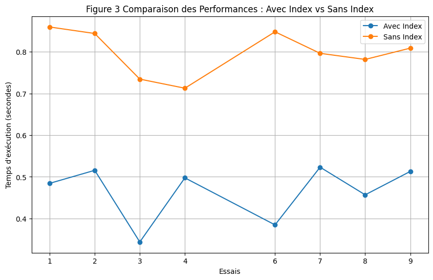

```python
import matplotlib.pyplot as plt

temps_avec_index = [0.484375, 0.515625, 0.34375, 0.49755, 0.38475, 0.52315, 0.45685, 0.51295]
temps_sans_index = [0.859375, 0.84375, 0.734375, 0.71255, 0.84785, 0.79625, 0.78155, 0.80865]

# Les indices pour l'axe des x
indices = [1, 2, 3,4,6,7,8,9]

plt.figure(figsize=(10, 6))
plt.plot(indices, temps_avec_index, label='Avec Index', marker='o')
plt.plot(indices, temps_sans_index, label='Sans Index', marker='o')

plt.title('Figure 3 Comparaison des Performances : Avec Index vs Sans Index')
plt.xlabel('Essais')
plt.ylabel('Temps d\'exécution (secondes)')
plt.xticks(indices)
plt.legend()
plt.grid(True)
plt.show()
```

## Compte Rendu d'Évaluation des Performances : MongoDB Avec Index vs Sans Index

Cette évaluation avait pour but de comparer les performances des requêtes dans MongoDB avec et sans l'utilisation d'index. L'objectif était de déterminer l'impact de l'indexation sur les temps d'exécution pour des requêtes sur un ensemble de données CSV.

### Conditions Expérimentales

- **Version Python :** Python 3.11.3
- **Machine Utilisée :** Ordinateur portable équipé d'un processeur Intel Core i3-1215U et de 8 Go de RAM.
- **Environnement MongoDB :** MongoDB 5.0, utilisé depuis une image docker.
- **Bibliothèque MongoDB Python :** PyMongo 4.2.
- **Date des Expériences :** Les tests ont été effectués le même jour.
- **Charge de la Machine :** La machine était dans des conditions de charge similaires pour les deux expériences.

### Résultats

- Test 1 : 0.484375 secondes
- Test 2 : 0.515625 secondes
- Test 3 : 0.34375 secondes
- Test 4 : 0.49755 secondes
- Test 5 : 0.38475 secondes
- Test 6 : 0.52315 secondes
- Test 7 : 0.45685 secondes
- Test 8 : 0.51295 secondes

- Test 1 : 0.859375 secondes
- Test 2 : 0.84375 secondes
- Test 3 : 0.734375 secondes
- Test 4 : 0.71255 secondes
- Test 5 : 0.84785 secondes
- Test 6 : 0.79625 secondes
- Test 7 : 0.78155 secondes
- Test 8 : 0.80865 secondes

### Interprétation des Résultats

# Conclusion : Redis, MongoDB et JSON dans la Gestion de Données

## Redis : Rapide et Réactif

Redis est un système de base de données qui travaille directement avec la mémoire de l'ordinateur, ce qui le rend super rapide. Il est parfait pour des tâches qui nécessitent une réponse immédiate, comme les chats en ligne ou les jeux. Redis est aussi vraiment bon pour gérer des données qui changent souvent, grâce à ses outils simples mais puissants.

## MongoDB : Flexible et Facile à Utiliser

MongoDB est un type différent de base de données qui stocke les informations un peu comme des documents JSON, ce qui le rend très pratique pour travailler avec des données variées. Il n'a pas besoin de structures rigides, donc on peut facilement ajouter ou changer des informations. C'est super pour des gros projets où les données peuvent être différentes et doivent être accessibles rapidement.

## JSON : Le Langage Commun

JSON est une façon simple d'écrire des données qui peut être lue par beaucoup de langages de programmation. C'est comme un langage commun qui aide les ordinateurs à se comprendre, surtout quand ils partagent des informations sur internet. C'est pratique parce que c'est facile à lire et à écrire, autant pour les humains que pour les machines.

## En Résumé

En utilisant Redis, MongoDB et JSON ensemble, on crée une super équipe pour gérer des données. Redis apporte la vitesse, MongoDB offre la flexibilité, et JSON fait en sorte que tout soit facile à utiliser et à partager. C'est un mélange parfait pour des applications modernes qui ont besoin de gérer beaucoup d'informations de manière efficace et rapide.